# In Course Exercise 7

Brooke Anderson

September 28, 2015

```r
library(knitr)
library(dplyr)
library(tidyr)
library(ggplot2)
library(gridExtra)
library(ggthemes)
library(scales)
```

## Preliminaries

- Download and read in the example data `recent-grads.csv`. Call the dataframe `grads`
- Create a summarized dataframe from this data that includes one row for each category of major, the percent of women graduates from that major category (the sum of the number of women for each major in that category divided by the sum of the number of women and men for each major in the category), and the average of the median salary for majors in that category. Call this summarized dataframe `major_cats`.
- Plot the relationship between the percent women in a major category (x-axis) versus the average of the median salary for the category. Label the major cateogries with (1) the highest median salary and (2) the highest percent of women. Try to print out the x-axis as a percent and the y-axis as dollars using the `scales` package and the functions `scale_x_continuous` and `scale_y_continuous` with the `label=` option.

### Example R code

Download and read in the example data in `recent-grads.csv`. Call the dataframe `grads`:

```r
grads <- read.csv("data/recent-grads.csv", sep = ",")
head(grads)
```

```
##   Rank Major_code                                     Major Major_category
## 1    1       2419                     PETROLEUM ENGINEERING    Engineering
## 2    2       2416            MINING AND MINERAL ENGINEERING    Engineering
## 3    3       2415                 METALLURGICAL ENGINEERING    Engineering
## 4    4       2417 NAVAL ARCHITECTURE AND MARINE ENGINEERING    Engineering
## 5    5       2405                      CHEMICAL ENGINEERING    Engineering
## 6    6       2418                       NUCLEAR ENGINEERING    Engineering
##   Total Sample_size   Men Women ShareWomen Employed Full_time Part_time
## 1  2339          36  2057   282  0.1205643     1976      1849       270
## 2   756           7   679    77  0.1018519      640       556       170
## 3   856           3   725   131  0.1530374      648       558       133
## 4  1258          16  1123   135  0.1073132      758      1069       150
## 5 32260         289 21239 11021  0.3416305    25694     23170      5180
## 6  2573          17  2200   373  0.1449670     1857      2038       264
##   Full_time_year_round Unemployed Unemployment_rate Median P25th  P75th
## 1                 1207         37        0.01838053 110000 95000 125000
## 2                  388         85        0.11724138  75000 55000  90000
## 3                  340         16        0.02409639  73000 50000 105000
## 4                  692         40        0.05012531  70000 43000  80000
## 5                16697       1672        0.06109771  65000 50000  75000
## 6                 1449        400        0.17722641  65000 50000 102000
##   College_jobs Non_college_jobs Low_wage_jobs
## 1         1534              364           193
## 2          350              257            50
## 3          456              176             0
## 4          529              102             0
## 5        18314             4440           972
## 6         1142              657           244
```

Create a summarized dataframe from this data that includes one row for each category of major, the percent of women graduates from that major category (the sum of the number of women for each major in that category divided by the sum of the number of women and men for each major in the category), and the average of the median salary for majors in that category. Call this summarized dataframe `major_cats`.

```r
major_cats <- group_by(grads, Major_category) %>%
        summarize(perc_women = sum(Women) / (sum(Women) + sum(Men)),
                  ave_median = mean(Median))

interesting_points <- subset(major_cats, ave_median == max(ave_median) |
                                     perc_women == max(perc_women))
```

Plot the relationship between the percent women in a major category (x-axis) versus the average of the median salary for the category. Label the major cateogries with (1) the highest median salary and (2) the highest percent of women. Try to print out the x-axis as a percent and the y-axis as dollars using the `scales` package and the functions `scale_x_continuous` and `scale_y_continuous` with the `label=` option.

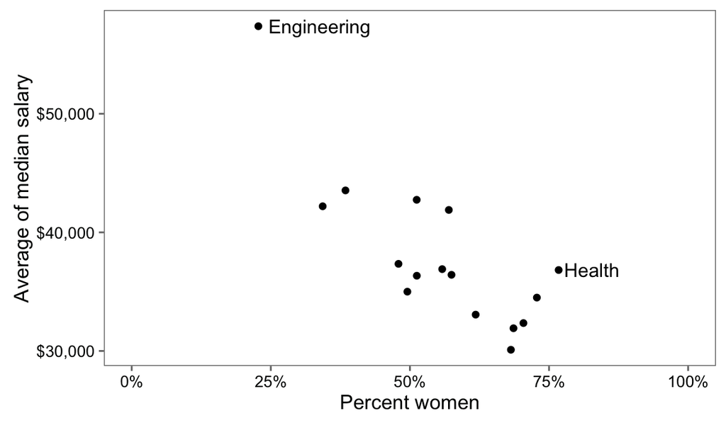

```r
ggplot(major_cats, aes(x = perc_women, y = ave_median)) +
        geom_point() +
        theme_few() +
        scale_x_continuous("Percent women", labels = percent,
                           limits = c(0, 1)) +
        scale_y_continuous("Average of median salary",
                           labels = dollar) +
        geom_text(data = interesting_points, aes(label = Major_category),
                  hjust = -0.1, size = 4)
```

## Exploring data using loops

- From the summarized dataframe you created, `major_cats`, pull out the vector that lists all the categories. Name that vector `categories`. Use the `data.frame()` command to create a new dataframe, `incat_rels` (for “in-category relationships”), where the column `cat` gives each of these categories, and the columns `n`, `est` and `se` are (currently) filled with missing values (`NA`).
- Loop through all these major categories. For the subset of majors within each category, fit a regression of median salary on percent of women in the major. Save the point estimate and standard error for each of these regressions in the `est` and `se` columns of the `incat_rels` dataframe. Save the number of majors in each category as the `n` column. Because you can’t fit a regression with a slope and intecept if there is only one observation, remove the `Interdisciplinary` category from your `incat_rels` dataframe before you run the loop.
- Perform the following changes on the `incat_rels` dataframe: (1) Add columns for the low and high values of the 95% confidence intervals; (2) Rearrange to go from the lowest to highest values of `est`.
- Plot each of these within-major-category estimates and their 95% CIs. Re-assign the levels of the `cat` column so the plot will have a meaningful order. You’ll want to use `geom_segment()` and `geom_point()` to make this plot. If you find that this crashes your R session when you do it, you may want to follow the example code precisely– I’ve found R can have some problems with `geom_segments()` (but they’re worth the effort).

### Example R code

From the summarized dataframe you created, `major_cats`, pull out the vector that lists all the categories. Name that vector `categories`. Use the `data.frame()` command to create a new dataframe, `incat_rels` (for “in-category relationships”), where the column `cat` gives each of these categories, and the columns `n`, `est` and `se` are (currently) filled with missing values (`NA`):

```r
categories <- major_cats$Major_category

incat_rels <- data.frame(cat = categories, n = NA, est = NA, se = NA)
incat_rels
```

```
##                                    cat  n est se
## 1      Agriculture & Natural Resources NA  NA NA
## 2                                 Arts NA  NA NA
## 3               Biology & Life Science NA  NA NA
## 4                             Business NA  NA NA
## 5          Communications & Journalism NA  NA NA
## 6              Computers & Mathematics NA  NA NA
## 7                            Education NA  NA NA
## 8                          Engineering NA  NA NA
## 9                               Health NA  NA NA
## 10           Humanities & Liberal Arts NA  NA NA
## 11 Industrial Arts & Consumer Services NA  NA NA
## 12                   Interdisciplinary NA  NA NA
## 13                 Law & Public Policy NA  NA NA
## 14                   Physical Sciences NA  NA NA
## 15            Psychology & Social Work NA  NA NA
## 16                      Social Science NA  NA NA
```

Loop through all these major categories. For the subset of majors within each category, fit a regression of median salary on percent of women in the major. Save the point estimate and standard error for each of these regressions in the `est` and `se` columns of the `incat_rels` dataframe. Save the number of majors in each category as the `n` column. Because you can’t fit a regression with a slope and intecept if there is only one observation, remove the `Interdisciplinary` category from your `incat_rels` dataframe before you run the loop.

Try setting `i <- 1` first and doing all of this for the first major category:

```r
incat_rels <- subset(incat_rels, cat != "Interdisciplinary")

i <- 1
incat_rels$cat[i]
```

```
## [1] Agriculture & Natural Resources
## 16 Levels: Agriculture & Natural Resources Arts ... Social Science
```

```r
major <- subset(grads, Major_category == incat_rels$cat[i])
major
```

```
##     Rank Major_code                                 Major
## 22    22       1104                          FOOD SCIENCE
## 64    64       1101 AGRICULTURE PRODUCTION AND MANAGEMENT
## 65    65       1100                   GENERAL AGRICULTURE
## 72    72       1102                AGRICULTURAL ECONOMICS
## 108  108       1303          NATURAL RESOURCES MANAGEMENT
## 112  112       1302                              FORESTRY
## 113  113       1106                          SOIL SCIENCE
## 144  144       1105            PLANT SCIENCE AND AGRONOMY
## 153  153       1103                       ANIMAL SCIENCES
## 162  162       1199             MISCELLANEOUS AGRICULTURE
##                      Major_category Total Sample_size   Men Women
## 22  Agriculture & Natural Resources  4361          36 99743 28576
## 64  Agriculture & Natural Resources 14240         273  7426 10874
## 65  Agriculture & Natural Resources 10399         158  1761  1874
```

[output cut: 40 more lines]

```r
incat_rels[i, "n"] <- nrow(major)
head(incat_rels, 3)
```

```
##                               cat  n est se
## 1 Agriculture & Natural Resources 10  NA NA
## 2                            Arts NA  NA NA
## 3          Biology & Life Science NA  NA NA
```

```r
incat_mod <- lm(Median ~ ShareWomen, data = major)
summary(incat_mod)$coefficients
```

```
##              Estimate Std. Error   t value     Pr(>|t|)
## (Intercept)  57772.54   4128.606 13.993234 6.595477e-07
## ShareWomen  -33777.71   6438.019 -5.246599 7.770365e-04
```

```r
incat_rels[i, c("est", "se")] <- summary(incat_mod)$coefficients[2, 1:2]
head(incat_rels, 3)
```

```
##                               cat  n       est       se
## 1 Agriculture & Natural Resources 10 -33777.71 6438.019
## 2                            Arts NA        NA       NA
## 3          Biology & Life Science NA        NA       NA
```

Now try expanding this to a loop:

```r
for(i in 1:nrow(incat_rels)){
        major <- subset(grads, Major_category == incat_rels$cat[i])
        incat_rels[i, "n"] <- nrow(major)

        if(incat_rels[i, "n"] > 1){
                incat_mod <- lm(Median ~ ShareWomen, data = major)
                incat_rels[i, c("est", "se")] <-
                        summary(incat_mod)$coefficients["ShareWomen", 1:2]
        }
}
incat_rels
```

```
##                                    cat  n        est        se
## 1      Agriculture & Natural Resources 10 -33777.708  6438.019
## 2                                 Arts  8 -32849.930 17850.624
## 3               Biology & Life Science 14  -4297.672  6765.605
## 4                             Business 13 -14150.470 12889.064
## 5          Communications & Journalism  4  -2654.517  2237.627
## 6              Computers & Mathematics 11   1283.040  6267.702
## 7                            Education 16 -10067.692  4972.055
## 8                          Engineering 29 -28531.202 16091.443
## 9                               Health 12  -7587.325  9271.110
## 10           Humanities & Liberal Arts 15  -5723.426  5720.050
## 11 Industrial Arts & Consumer Services  7 -18850.965 14517.508
## 13                 Law & Public Policy  5 -18934.394 25081.678
## 14                   Physical Sciences 10  -4454.577 14358.858
## 15            Psychology & Social Work  9 -26330.257 10807.359
## 16                      Social Science  9 -25728.702 13158.466
```

Perform the following changes on the `incat_rels` dataframe:

- Add columns for the low and high values of the 95% confidence intervals
- Rearrange to go from the lowest to highest values of `est`

```r
incat_rels <- mutate(incat_rels,
                     low_ci = est - 1.96 * se,
                     high_ci = est + 1.96 * se) %>%
        arrange(est)
incat_rels
```

```
##                                    cat  n        est        se     low_ci
## 1      Agriculture & Natural Resources 10 -33777.708  6438.019 -46396.226
## 2                                 Arts  8 -32849.930 17850.624 -67837.153
## 3                          Engineering 29 -28531.202 16091.443 -60070.430
## 4             Psychology & Social Work  9 -26330.257 10807.359 -47512.681
## 5                       Social Science  9 -25728.702 13158.466 -51519.296
## 6                  Law & Public Policy  5 -18934.394 25081.678 -68094.482
## 7  Industrial Arts & Consumer Services  7 -18850.965 14517.508 -47305.280
## 8                             Business 13 -14150.470 12889.064 -39413.035
## 9                            Education 16 -10067.692  4972.055 -19812.920
## 10                              Health 12  -7587.325  9271.110 -25758.700
## 11           Humanities & Liberal Arts 15  -5723.426  5720.050 -16934.723
## 12                   Physical Sciences 10  -4454.577 14358.858 -32597.939
## 13              Biology & Life Science 14  -4297.672  6765.605 -17558.257
## 14         Communications & Journalism  4  -2654.517  2237.627  -7040.267
```

[output cut: 17 more lines]

Plot each of these within-major-category estimates and their 95% CIs. Re-assign the levels of the `cat` column so the plot will have a meaningful order. You’ll want to use `geom_segment()` and `geom_point()` to make this plot. If you find that this crashes your R session when you do it, you may want to follow the example code precisely– I’ve found R can have some problems with `geom_segments()` (but they’re worth the effort).

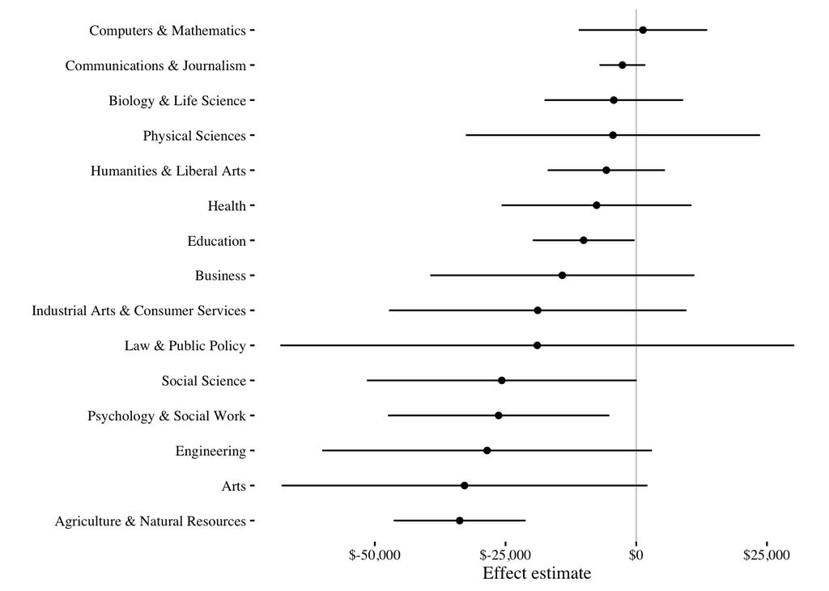

```r
incat_rels$cat <- factor(incat_rels$cat, levels = incat_rels$cat)
ggplot(incat_rels, aes(x = low_ci, y = cat)) +
        geom_vline(aes(xintercept = 0), color = "lightgray") +
        geom_segment(aes(xend = high_ci, yend = cat)) +
        geom_point(aes(x = est, y = cat)) +
        ylab("") +
        scale_x_continuous("Effect estimate", label = dollar) +
        theme_tufte()
```

## Incorporating functions

- Write a short function that can take a vector with three values– point estimate, lower CI, and upper CI– and output a single character vector with these pasted together in an attactive way (e.g., “-33,800 (-46,400, -21,200)”).
- Apply this function to the `incat_rels` columns for `est`, `low_ci`, and `high_ci`. Save the output to a new column in `incat_rels` called `Estimates`.
- Print out a table with the pretty estimates. Use the column names “Major category” and “Effect estimate”. Use `kable()` from the `knitr` package to make the table print out in markdown.

### Example R code

Write a short function that can take a vector with three values– point estimate, lower CI, and upper CI– and output a single character vector with these pasted together in an attactive way (e.g., “-33,800 (-46,400, -21,200)”):

```r
pretty_ests <- function(est_vec){
        est_vec <- prettyNum(round(est_vec, -2), big.mark = ",")
        out <- paste0(est_vec[1], " (", est_vec[2], ", ", est_vec[3], ")")
        return(out)
}
pretty_ests(c(-33777.7, -46396.23, -21159.19))
```

```
## [1] "-33,800 (-46,400, -21,200)"
```

Apply this function to the `incat_rels` columns for `est`, `low_ci`, and `high_ci`.

```r
apply(incat_rels[ , c("est", "low_ci", "high_ci")], 1, pretty_ests)
```

```
##  [1] "-33,800 (-46,400, -21,200)" "-32,800 (-67,800, 2,100)"
##  [3] "-28,500 (-60,100, 3,000)"   "-26,300 (-47,500, -5,100)"
##  [5] "-25,700 (-51,500, 100)"     "-18,900 (-68,100, 30,200)"
##  [7] "-18,900 (-47,300, 9,600)"   "-14,200 (-39,400, 11,100)"
##  [9] "-10,100 (-19,800, -300)"    "-7,600 (-25,800, 10,600)"
## [11] "-5,700 (-16,900, 5,500)"    "-4,500 (-32,600, 23,700)"
## [13] "-4,300 (-17,600, 9,000)"    "-2,700 (-7,000, 1,700)"
## [15] "1,300 (-11,000, 13,600)"
```

Save the output to a new column in `incat_rels` called `Estimates`:

```r
incat_rels$Estimate <- apply(incat_rels[ , c("est", "low_ci", "high_ci")],
                    1, pretty_ests)
```

Print out a table with the pretty estimates. Use the column names “Major category” and “Effect estimate”. Use `kable()` from the `knitr` package to make the table print out in markdown.

```r
out_tab <- mutate(incat_rels,
                  Category = paste0(cat, " (N = ", n, ")")) %>%
        select(Category, Estimate)
colnames(out_tab) <- c("Major category", "Effect estimate")
kable(out_tab, format = "markdown")
```

| Major category | Effect estimate |
| --- | --- |
| Agriculture & Natural Resources (N = 10) | -33,800 (-46,400, -21,200) |
| Arts (N = 8) | -32,800 (-67,800, 2,100) |
| Engineering (N = 29) | -28,500 (-60,100, 3,000) |
| Psychology & Social Work (N = 9) | -26,300 (-47,500, -5,100) |
| Social Science (N = 9) | -25,700 (-51,500, 100) |
| Law & Public Policy (N = 5) | -18,900 (-68,100, 30,200) |
| Industrial Arts & Consumer Services (N = 7) | -18,900 (-47,300, 9,600) |
| Business (N = 13) | -14,200 (-39,400, 11,100) |
| Education (N = 16) | -10,100 (-19,800, -300) |
| Health (N = 12) | -7,600 (-25,800, 10,600) |
| Humanities & Liberal Arts (N = 15) | -5,700 (-16,900, 5,500) |
| Physical Sciences (N = 10) | -4,500 (-32,600, 23,700) |
| Biology & Life Science (N = 14) | -4,300 (-17,600, 9,000) |
| Communications & Journalism (N = 4) | -2,700 (-7,000, 1,700) |
| Computers & Mathematics (N = 11) | 1,300 (-11,000, 13,600) |